# Analysis_Arkaute

Javier Porras

2023-12-04

## Dudas

- Podríamos tener distintos scripts, pero luego “llamar” a estos scripts en distintos chunks?
- Por qué me aparece ahora en el Knit todas las respuestas de la consola de R? si pone “(echo = FALSE)”

## Cosas qué hacer

- Ir organizando el workflow de este .Rmd.
- Mirar si hay correlaciones entre alturas y circunferencias para completar los datos de biomasa de muestreos 0, 1 y 2.
- Sensitivity test de Z
- Rank abundance distribution analysis
- Mirar si podemos utilizar varias ecuaciones en función de la especie.
- Mirar diferencias en la distribución de los datos de biomasa una vez aplicada la ecuación y después de calcular las biomasas por especie y plot. Lo esperable es que una vez estimada la biomasa en base a la abundancia el histograma sea más “alargado” en la cola.

## Opening and checking flora data

In this script we take a look to the shape of our collected data.

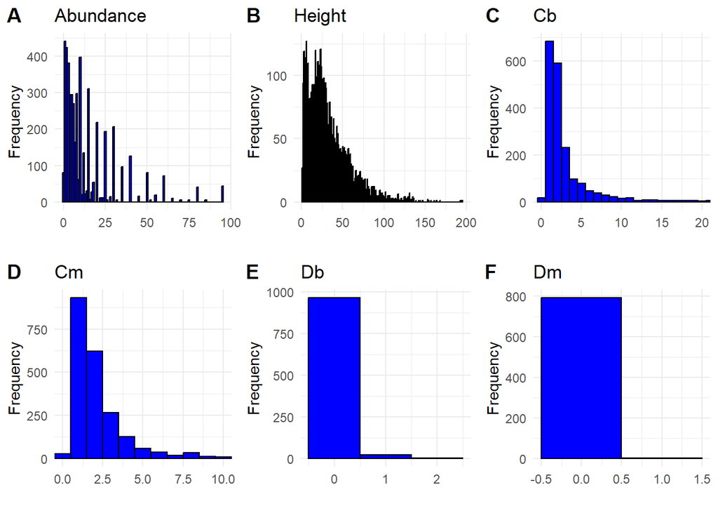

We have asymmetric data.

## Graphs for dynamics

Graph of biomass, diversity and abundance along samplings. Each boxplot contains 4 points (4 replicates per treatment):

- Biomass: the total biomass (addition of all individual data of biomass at species level)
- Diversity: the total number of species per replicate.
- Abundance: The addition of all abundance data in order to know the total coverage of each replicate. No species-level information here.

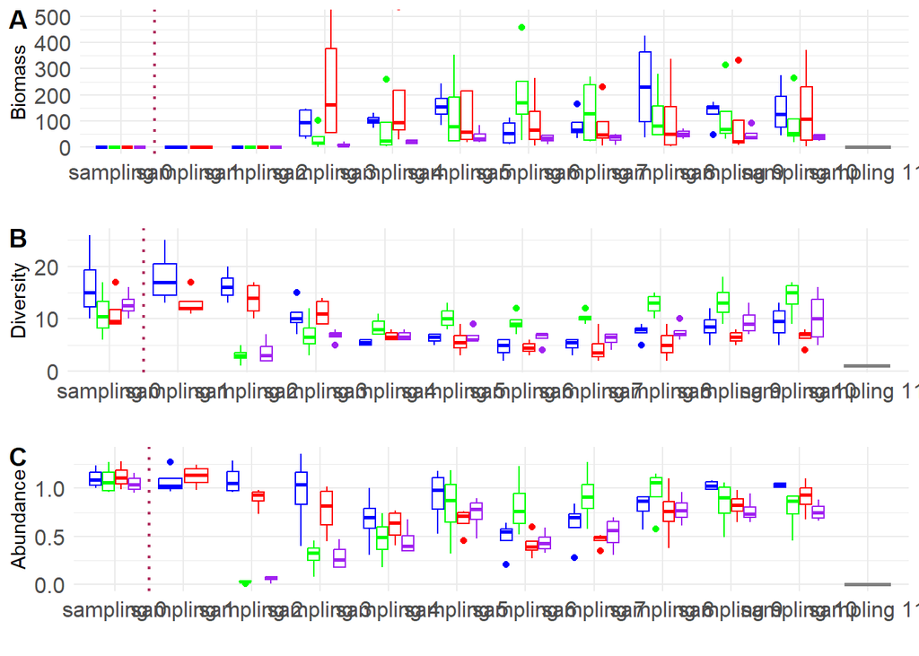

In the next graph we can see the aggregated differences between treatments:

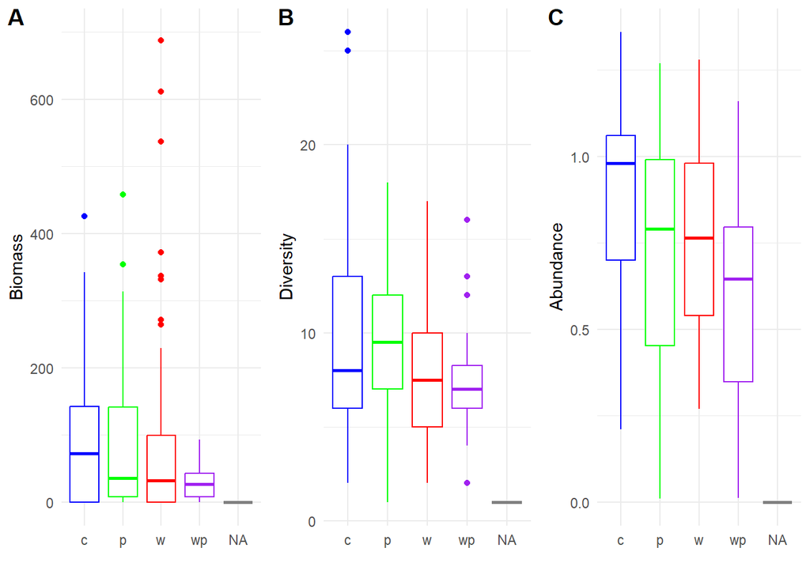